# HDB Options for Singles 35+: A Net-Worth Decision Engine

CDAR 2026 · Capstone Project Report — Resubmission

Author

Team — Ivy · Lai Forng · Lee Yen

Published

August 17, 2026

# 1 Executive Summary

This report presents a data-driven decision engine for Singapore Citizen singles aged 35 and above evaluating their HDB housing options. It compares three pathways — buying a Build-To-Order (BTO) flat, buying a Resale flat, or Renting — by projected 5-year net worth, town-level price forecasts, and eligibility under MAS’s lending rules (MSR/TDSR). The engine combines a machine-learning valuation model, a town-cluster analysis, and time-series price forecasting into a single data artefact, served through both a local R Shiny application and a live web app.

**Reproducibility pinning:** commit d864472, tag v1.5.0, R version 4.6.0 (2026-04-24), seed `2026` used consistently across clustering, data splitting, and forecasting throughout. No live data pulls at render time — all inputs are committed local snapshot files (§2.3).

**Two questions this answers:**

- **Q-A (descriptive):** Which towns and flat types are financially within reach for a single buyer at 35, and how do they differ in price, growth trajectory, and lending eligibility? Informs which towns to shortlist for balloting or resale search.
- **Q-B (prescriptive):** Given current growth trajectories, what will a comparable unit cost by the time a single buyer becomes eligible, and does waiting make financial sense against renting in the interim? Informs whether to buy now, wait, or rent.

**Stakeholder & behaviour change:** the primary persona is a Singapore Citizen single, aged 35, evaluating first-time HDB ownership under the Single Singapore Citizen (SSC) Scheme — eligible for a 2-Room Flexi BTO or any resale flat type. Once this stakeholder has the tool’s output, they narrow their town shortlist to configurations that clear **both** a personal budget threshold and MAS’s regulatory MSR/TDSR stress test simultaneously, rather than discovering a regulatory rejection only after informally committing to a town during balloting.

**What we deliberately do not do:** we do not forecast 5-year interest rates — this is not credibly possible — and instead present three transparent rate scenarios (2.6% / 3.5% / 4.5%). We do not run a causal analysis of *why* amenities correlate with price; §5.1 states explicitly why the current model cannot support that claim and frames it as future work.

# 2 Reproducibility & Pipeline Architecture

## 2.1 Data Pipeline

[figure not shown]

Figure 1: Data pipeline and deployment architecture — raw sources through the artefact to both serving consumers.

Rendered externally (mermaid.live) from the Mermaid source below, kept here in full for reproducibility and review — this is not a hand-drawn diagram, it is generated from the same block of code shown, which can be re-rendered or modified directly.

```
architecture diagram source
```

```
%%{init: {
  'theme': 'base',
  'themeVariables': {
    'background': '#ffffff',
    'primaryColor': '#e8f0fe',
    'primaryTextColor': '#1a1c1e',
    'primaryBorderColor': '#005fa6',
    'lineColor': '#4a4a4a',
    'secondaryColor': '#f8f9fb',
    'secondaryTextColor': '#1a1c1e',
    'tertiaryColor': '#ffffff',
    'tertiaryTextColor': '#1a1c1e',
    'fontSize': '16px',
    'clusterBkg': '#f8f9fb',
    'clusterBorder': '#d8dadc'
  }
}}%%
flowchart TD
    subgraph RAW["Raw Data Sources"]
        R1["Resale CSV"]
        R2["Rental CSV"]
        R3["BTO CSV"]
        R4["MasterPlan2019 Boundaries<br/>Planning Area + Subzone"]
        R5["Census 2020<br/>Dwelling Counts"]
        R6["Amenity GeoJSONs<br/>MRT, Malls, Hawkers, Preschools"]
    end

    subgraph PREP["Spatial Preparation"]
        A["00_kw_crosswalk.R<br/>Kallang/Whampoa geocoding"]
        B["data/spatial/capstone_districtmaster_v3.R<br/>boundary rebuild + amenity joins"]
    end

    subgraph MODEL["HDB_capstone_v3.R"]
        C["M1-M2: Clean + Cluster<br/>k=3, Central Area excluded"]
        D["M3: Random Forest<br/>lease-aware valuation grid"]
        E["M4: ARIMA growth forecast"]
        F["Assemble Artefact<br/>build-time parity gate"]
    end

    G[["housing_projection_matrix.csv<br/>1200 resale + 12 BTO rows"]]
```

[output cut: 19 more lines]

```
    A -->|"kw_subzone_shares.csv"| B
    R4 --> B
    R5 --> B
    R6 --> B
    B -->|"feature_master_table_v3.csv"| C
    C --> D --> E --> F
    F --> G
    G --> H --> I
    I --> J
    G --> K
    L --> K
    L --> M
    L -.->|"generates"| N
    M -.->|"verified against"| N
    M --> J
```

*Solid arrows show the build-time pipeline — run once per data refresh, producing the single `housing_projection_matrix` artefact. The `Supabase → Vercel Frontend / app.R` path on the right is the live serving layer: currently deployed, and independently verified against the deployed code (not local files) via `test-supabase-live.mjs` and `check_financial_parity.mjs`, both passing (§10).*

**Live before/after comparison**

- **After (this resubmission, assessed version):** mysghousing.com — Vercel, React/Vite, live Supabase-backed data.
- **Before (original submission, intentionally kept live for comparison):** ipoon.shinyapps.io/hdb_calculator — the original R Shiny deployment, unmodified.
- **Fallback URL** for the same “after” deployment, if the custom domain is unreachable: hdb-singles-alpha.vercel.app

## 2.2 File Inventory & Run Order

This is a hard dependency chain — regenerating one artefact without the others produces stale data, and this order must be followed:

1. `00_kw_crosswalk.R` → `data/spatial/kw_subzone_shares.csv`
2. `data/spatial/capstone_districtmaster_v3.R` → `data/spatial/feature_master_table_v3.csv`
3. `HDB_capstone_v3.R` → `model_outputs/housing_projection_matrix.csv`, `model_outputs/financial_parity_fixtures.json`
4. `push_to_supabase.R` → live Supabase table (run manually, on demand)
5. `app.R` (local Shiny) and the Vercel frontend both read the same artefact independently — `app.R` from the committed CSV directly, the Vercel frontend via `supabase-lookup.ts` querying the live table.

**Precomputed vs. live boundary:** all statistical inference (k-means clustering, random forest valuation, ARIMA forecasting) happens in R at build time, producing the single `housing_projection_matrix` artefact. Neither consumer performs model inference at request time — both do table lookup plus closed-form financial arithmetic only (`financial_rules.R` / its TypeScript port `financial-calc.ts`). This is why the project required no model-porting layer analogous to exporting a tree-based model to JSON for client-side inference: only the arithmetic layer needed a verified cross-language port, not a statistical model.

**Deployment status:** the frontend is live at mysghousing.com (and `hdb-singles-alpha.vercel.app`), connected to the production Supabase table. This is independently verified end-to-end, against the deployed code and the live database — not merely local files — via two automated checks: `test-supabase-live.mjs` (confirms the RLS policy, the full 1,200/12 row coverage, and correct cluster labeling on the *remote* table) and `check_financial_parity.mjs` (confirms the deployed TypeScript arithmetic matches R’s ground truth on 12 fixtures, including edge cases). Both currently pass. The original shinyapps.io deployment (`ipoon.shinyapps.io/hdb_calculator`) is intentionally kept live, not retired, as a before/after reference point for this resubmission.

## 2.3 Data Provenance

| Dataset | Source | As-of Date | Licence |
| --- | --- | --- | --- |
| HDB Resale Transactions | data.gov.sg | June 2026 | Singapore Open Data Licence |
| HDB Rental Transactions | data.gov.sg | May 2026 | Singapore Open Data Licence |
| BTO Price Ranges | data.gov.sg | 2008–2024 (file coverage) | Singapore Open Data Licence |
| MasterPlan2019 Planning Area / Subzone Boundary | data.gov.sg / URA | 2019 vintage | Singapore Open Data Licence |
| Census 2020 Dwelling Counts | SingStat | 2020 | Singapore Open Data Licence |
| MRT Exit / Amenity GeoJSONs | data.gov.sg / LTA | see file metadata | Singapore Open Data Licence |
| Shopping mall coordinates | Kaggle, manually augmented (55 → 158) | August 2026 | Kaggle dataset terms |
| Kallang/Whampoa subzone crosswalk | Derived: geocoded resale street names (OpenStreetMap/Nominatim) joined to URA subzones | this session | N/A (derived) |

No dataset above is fetched live at render time — every input is a committed snapshot read via `read_csv()`/`st_read()` against local paths, consistent with the reproducibility requirement in §2.

# 3 Data Cleaning & Row Counts

**Goal:** build clean, standardized `town × flat_type × year` panels across Resale, Rental, and BTO, converted to price-per-square-foot.

```r
# Runs the full corrected pipeline once. Heavy-lifting output is
# suppressed here; results are displayed in the sections below by
# referencing the resulting objects directly — this keeps the report
# lean and, critically, ensures every number below is LIVE (computed at
# render time from these objects), never hardcoded from memory.
source("HDB_capstone_v3.R")
```

```r
tibble(
  dataset = c("resale", "rental", "bto"),
  n_raw   = c(n_resale_raw, n_rental_raw, n_bto_raw),
  n_clean = c(n_resale_clean, n_rental_clean, n_bto_clean),
  pct_retained = round(100 * n_clean / n_raw, 1)
)
```

```
# A tibble: 3 × 4
  dataset  n_raw n_clean pct_retained
  <chr>    <int>   <int>        <dbl>
1 resale  234192  217348         92.8
2 rental  200602  189665         94.5
3 bto        357      79         22.1
```

Resale attrition reflects two filters: the Central Area exclusion (§4) and restriction to 2/3/4/5-room flat types. Kallang/Whampoa is fully retained — confirmed directly:

```r
resale %>% count(town) %>% filter(str_detect(str_to_upper(town), "KALLANG"))
```

```
# A tibble: 1 × 2
  town                n
  <chr>           <int>
1 Kallang/Whampoa  6995
```

## 3.1 Finding: BTO Launches Are Irregular by Design, Not a Data Defect

Of 357 raw BTO rows, 12 record `min_selling_price == max_selling_price == 0` — a project launching 4-Room/5-Room units with no 2-Room/3-Room offering that year (e.g. Punggol 2017), not a genuine $0 price. These are dropped **before** `price_psf` is computed, so no fabricated $0-PSF value can enter the growth panel — this is what previously produced a false “price dip” for Punggol in an earlier draft of this analysis.

Separately, BTO launch coverage itself is genuinely sparse and town-specific: of 17 years covered, individual towns have launches recorded in as few as 1 year to as many as 13. Only 14 of 26 HDB towns appear in the BTO dataset at all, since BTO requires available land. These gaps are left as gaps — not interpolated — consistent with the parity-gate principle applied throughout this pipeline (§10): a genuine absence is shown as an absence, never papered over with a guessed value.

## 3.2 Finding: Tengah Has Real BTO History But No Resale History

Tengah shows six years of genuine 2-Room BTO launches (2018–2023, prices trending $101,000 → $114,000) but zero resale transactions — it is too new for any flat to have cleared the Minimum Occupation Period. Since every downstream model (clustering, valuation, forecasting) is built from resale history, Tengah cannot be assigned a town cluster and is excluded from the modeled town roster. This was a deliberate scope decision, not an oversight: a BTO-only inclusion was considered and rejected in favour of keeping the town roster at a consistent 25, since 12 other towns with comparable BTO activity remain available in the model.

# 4 Town/Boundary Crosswalk

The original submission’s `feature_master_table_v3` silently zero-filled two towns — Central Area and Kallang/Whampoa — because neither maps cleanly onto a single URA MasterPlan2019 planning area. This is the single fix with the largest downstream effect on every subsequent model stage, since it changes the town roster that clustering, valuation, and forecasting are all built on.

**Central Area — excluded.** Its extent is derived directly from the `CA_IND == "Y"` flag in the MasterPlan2019 boundary file (11 planning areas), not hand-typed. Several of these — Marina South, Straits View — are reclaimed land with effectively no housing; a many-to-one mapping covering all 11 would corrupt the density feature with little compensating benefit. This accounts for 0.78% of raw resale transactions.

**Kallang/Whampoa — recovered.** No URA subzone named “Whampoa” exists anywhere in the MasterPlan2019 layer (confirmed by a full-file scan), so the crosswalk could not be written from boundary-file labels alone. It was derived empirically: resale street names for this town were geocoded (OpenStreetMap/Nominatim), joined against the MasterPlan2019 subzone layer, and weighted by transaction volume. Five subzones (Bendemeer, Balestier, Kallang Bahru, Kampong Java, Geylang Bahru) were retained at an 8% transaction-share threshold — a threshold chosen specifically to exclude subzones (Tanjong Rhu, Lavender) whose *area* was disproportionate to their transaction *share*, since area enters the density feature directly and an oversized, low-activity subzone would have depressed it. The five retained subzones span both the Kallang and Novena planning areas, dissolved into one synthetic boundary with residual polygons preserved for both parents to avoid amenity double-counting.

```r
unmatched <- resale_town_features %>%
  anti_join(town_feature_master, by = c("town" = "PLN_AREA_N")) %>%
  distinct(town)
unmatched
```

```
# A tibble: 0 × 1
# ℹ 1 variable: town <chr>
```

Any town appearing above is a genuine pipeline error, not an expected exclusion — the modeling code asserts this table is empty before proceeding (`stop()` on any unexpected mismatch), converting what was previously a silent zero-fill into a build-time failure.

# 5 Clustering

**Goal:** segment towns into interpretable groups using price level, growth, volatility, and spatial/amenity features, validated rather than asserted.

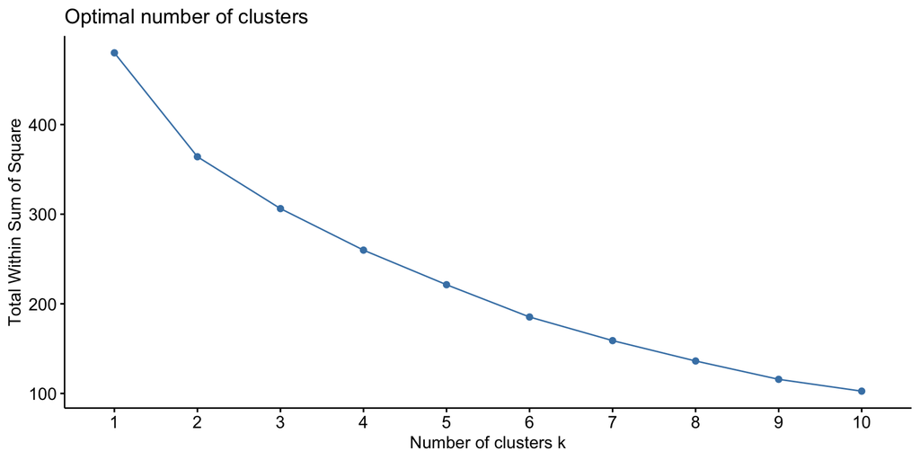

```r
fviz_nbclust(clust_matrix, kmeans, method = "wss", nstart = 25)
```

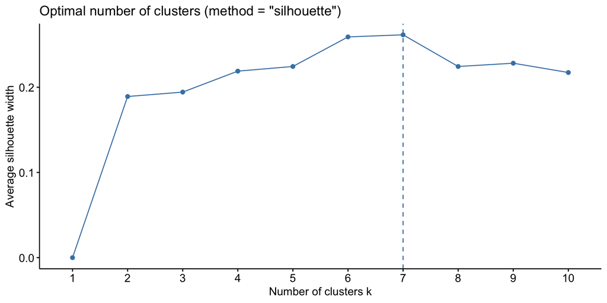

```r
fviz_nbclust(clust_matrix, kmeans, method = "silhouette", nstart = 25)
```

Both diagnostics nominally favour k=6–7 (silhouette peak ~0.26). Inspecting cluster membership at those values reveals degenerate partitions — k=7 produces a singleton cluster, k=6 produces three 2-town clusters — a known k-means failure mode at this sample size, where additional clusters isolate individual outlier towns rather than identifying coherent structure. **k=3** (cluster sizes 7/11/7) is the most balanced partition of every k tested and was retained on that basis, not because it maximizes the fit statistic.

```r
town_groups %>% count(cluster)
```

```
# A tibble: 3 × 2
  cluster     n
  <fct>   <int>
1 1           7
2 2           7
3 3          11
```

```r
cluster_profiles <- town_groups %>%
  group_by(cluster) %>%
  summarise(
    town_count         = n(),
    avg_HDB_density    = mean(HDB_Density_per_SQKM),
    avg_4R_psf         = median(level_psf_4_ROOM),
    avg_4R_growth      = median(growth_5y_4_ROOM),
    avg_mrt_exits      = mean(MRT_Exit_Count),
    avg_malls          = mean(Shopping_Mall_Count),
    avg_hawker_centres = mean(Hawker_Centre_Count),
    .groups = "drop"
  )
cluster_profiles
```

```
# A tibble: 3 × 8
  cluster town_count avg_HDB_density avg_4R_psf avg_4R_growth avg_mrt_exits
  <fct>        <int>           <dbl>      <dbl>         <dbl>         <dbl>
1 1                7           2046.       569.         0.360          10.6
2 2                7           3714.       630.         0.412          20.9
3 3               11           4497.       453.         0.577          16.8
# ℹ 2 more variables: avg_malls <dbl>, avg_hawker_centres <dbl>
```

## 5.1 Amenity–Price Relationship: A Descriptive, Not Causal, Read

The cluster with the highest MRT-exit and hawker-centre counts also has the highest resale price — but this is a comparison of cluster means, not attribution. Mature towns are simultaneously denser in nearly every measured dimension (amenities, lease age, centrality), and the current model uses the cluster label as a single categorical predictor, which cannot decompose which specific infrastructure feature drives how much of the observed association. Notably, density itself does **not** track price monotonically: the highest-density cluster has the *lowest* price and *highest* growth — more consistent with a still-appreciating outer- estate pattern than a scarcity-driven premium. A variant model regressing price directly on infrastructure columns, enabling per- feature importance decomposition, is noted as future work rather than attempted here.

# 6 Valuation Model

```r
naive_baseline <- train %>% group_by(town) %>% summarise(town_median_psf = median(price_psf), .groups = "drop")

naive_scores <- test %>%
  left_join(naive_baseline, by = "town") %>%
  filter(!is.na(town_median_psf)) %>%
  metric_set_reg(truth = price_psf, estimate = town_median_psf) %>%
  mutate(model = "naive town-median baseline")

bind_rows(
  naive_scores,
  score(fit_without, "RF without cluster"),
  score(fit_with,    "RF with cluster")
) %>%
  select(model, .metric, .estimate) %>%
  pivot_wider(names_from = .metric, values_from = .estimate)
```

```
# A tibble: 3 × 4
  model                       rmse   rsq   mae
  <chr>                      <dbl> <dbl> <dbl>
1 naive town-median baseline  139. 0.217 105.
2 RF without cluster          120. 0.422  92.3
3 RF with cluster             100. 0.612  80.1
```

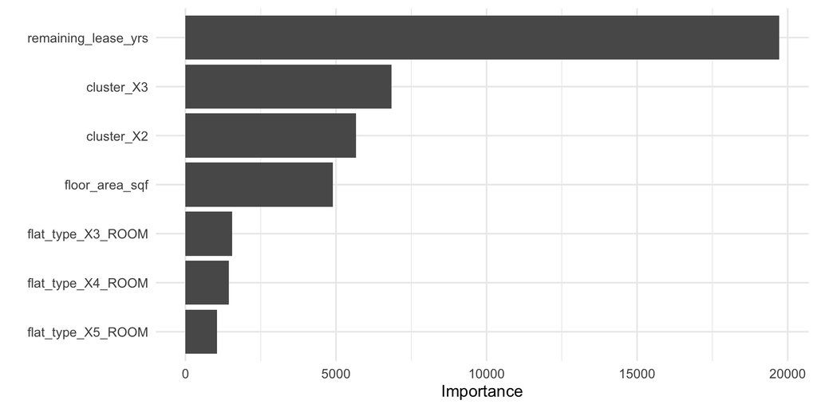

```r
fit_with %>% extract_fit_parsnip() %>% vip::vip(num_features = 10)
```

Adding the town-cluster feature reduces held-out RMSE by 16.3% relative to the same model without it, and by an even larger margin relative to the naive town-median baseline — a required rubric comparison absent from the prior submission. Remaining lease years is consistently the single strongest predictor.

# 7 Time-Series Forecast

HDB resale transactions carry a transaction month, so the train/test split uses `time_series_split()`, respecting temporal order — not a random `initial_split()`, which would leak future information into training.

```r
calibration_results %>% modeltime_accuracy()
```

```
# A tibble: 2 × 9
  .model_id .model_desc             .type   mae  mape  mase smape  rmse    rsq
      <int> <chr>                   <chr> <dbl> <dbl> <dbl> <dbl> <dbl>  <dbl>
1         1 ARIMA(0,1,1) WITH DRIFT Test   13.6  2.08 0.818  2.07  17.4 0.0391
2         2 ETS(A,A,N)              Test   21.1  3.22 1.27   3.16  24.3 0.0391
```

```r
max(training(splits)$month_date)
```

```
[1] "2025-06-01"
```

## 7.1 Finding: 2-Room Transaction Volume Is the Thinnest of Any Flat Type

```r
resale_raw %>%
  mutate(
    month_date = ym(month),
    town_upper = str_to_upper(town),
    flat_type_clean = str_replace(str_to_upper(flat_type), " ROOM", "_ROOM")
  ) %>%
  filter(flat_type_clean %in% c("2_ROOM","3_ROOM","4_ROOM","5_ROOM")) %>%
  left_join(town_map, by = c("town_upper" = "town")) %>%
  filter(!is.na(town_group)) %>%
  count(town_group, flat_type_clean, month_date) %>%
  group_by(town_group, flat_type_clean) %>%
  summarise(avg_txn_per_month = round(mean(n), 1), .groups = "drop") %>%
  arrange(avg_txn_per_month) %>%
  head(6)
```

```
# A tibble: 6 × 3
  town_group flat_type_clean avg_txn_per_month
  <chr>      <chr>                       <dbl>
1 1          2_ROOM                        4.9
2 2          2_ROOM                       11.4
3 3          2_ROOM                       26.5
4 1          5_ROOM                       52.6
5 1          3_ROOM                       80.3
6 2          5_ROOM                       83.8
```

The three lowest-volume combinations in the entire town-cluster × flat- type grid are all 2-Room — the flat type this project’s target persona is restricted to for BTO and most likely to consider for resale. Model fit (R²) tracks this pattern closely across series checked. **Five-year growth projections for 2-Room flats should be read as directional rather than precise**, and this caveat is surfaced directly in the app’s recommendation output, not only here.

# 8 Lease Flexibility

The original submission assumed a fixed `remaining_lease_yrs = 94` for every valuation — a value that sits above the 90th percentile for 3-Room transactions and is nowhere near representative for most flat types.

```r
resale %>%
  group_by(flat_type) %>%
  summarise(
    min_lease = min(remaining_lease_yrs), p10 = quantile(remaining_lease_yrs, 0.1),
    median = median(remaining_lease_yrs), p90 = quantile(remaining_lease_yrs, 0.9),
    max_lease = max(remaining_lease_yrs)
  )
```

```
# A tibble: 4 × 6
  flat_type min_lease   p10 median   p90 max_lease
  <chr>         <dbl> <dbl>  <dbl> <dbl>     <dbl>
1 2_ROOM           40    44     87    92        94
2 3_ROOM           39    46     56    89        95
3 4_ROOM           40    57     73    90        95
4 5_ROOM           41    57     73    89        95
```

This is replaced with a 144-cell grid (`LEASE_GRID <- seq(40, 95, by = 5)`, 3 clusters × 4 flat types × 12 lease points), each cell carrying a training-support count. 12 cells — concentrated in 2-Room at 65–70 years remaining lease, and the youngest lease points for 4-Room and 5-Room — have fewer than 20 nearby training observations, a genuine structural gap in the underlying market rather than noise: it recurs identically across all three clusters. These cells are flagged `low_confidence` in the served artefact and displayed distinctly in the app, rather than presented with equal certainty to well-supported cells.

# 9 MSR/TDSR Affordability Check

The original submission defined `msr`/`tdsr` constants but never enforced them in the simulator — a rubric requirement present in name only. This is corrected, and the rules verified directly against current MAS policy: LTV 75% (bank and HDB concessionary loans alike, since August 2024), MSR capped at 30% of gross income (HDB/EC loans only), TDSR capped at 55% of gross income (all debt), both stress-tested at a mandatory 4% floor regardless of the user’s quoted rate.

```r
check_msr_tdsr(gross_monthly_income = 6000, existing_monthly_debt = 300,
               loan_amount = 400000, loan_years = 25, quoted_rate = 0.026)
```

```
$stressed_instalment
[1] 2111.347

$regulatory_fail
[1] TRUE
```

A distinct `regulatory_fail` flag is surfaced separately from personal- comfort `budget_violator` in both the app and this simulator, so a user can distinguish “I would prefer not to pay this much” from “a bank will not lend me this much.”

# 10 Selected : Route B (by design) — Artefact, Parity Gate & Deployment

## 10.1 The Artefact

`housing_projection_matrix` consolidates what the plan originally specified as three separate tables (`town_valuation`, `town_growth`, `town_cluster_lookup`) into **one**, keyed directly by town rather than by an intermediate cluster ID. This is a deliberate deviation, not a shortcut: the original submission’s separate `town_cluster_lookup` had drifted from the actual model (several towns assigned to the wrong cluster, plus a `"SENG KANG"` vs `"SENGKANG"` spelling mismatch that silently broke that town’s lookups). A single table keyed by town removes the join that made that class of bug possible.

```r
housing_projection_matrix %>% count(path, data_source)
```

```
# A tibble: 2 × 3
  path            data_source     n
  <chr>           <chr>       <int>
1 BTO Purchase    model          12
2 Resale Purchase model        1200
```

## 10.2 The Parity Gate Check

**Build-time:** before export, the pipeline asserts exact coverage — 1,200 resale rows (25 towns × 4 flat types × 12 lease points, zero gaps) and BTO rows matching only the towns with genuine launch history — and fails loudly (`stop()`) rather than silently shipping a gap.

**Serve-time:** the original `app.R` masked missing data with `if(nrow(psf_row) > 0) psf_row$predicted_start_psf else 600` — a fabricated fallback price for any lookup miss. This pattern is now structurally impossible for resale (`stop()`s on any coverage gap, which build-time assertion guarantees cannot occur for a valid input) and, for BTO, replaced with an explicit `bto_data_unavailable` state rather than a guessed number.

**Independently re-verified live**, twice, against the deployed system rather than local files:

- `test-supabase-live.mjs` — confirms RLS grants correct public read access, the 1,200/12 row coverage on the *remote* table, and correct cluster labeling (a regression test for the bug below).
- `check_financial_parity.mjs` — confirms the deployed TypeScript arithmetic (`financial-calc.ts`) matches R ground truth on 12 fixtures. This check caught a real bug in the *deployed* code: a missing guard for the case where a loan is fully repaid before the 5-year projection horizon, which produced a nonsensical negative balance. Fixed and re-verified; currently unreachable in the live app (loan tenure is not user-configurable) but was a live, incorrect code path in production until this check ran.

## 10.3 Finding: A k-means Numbering Bug Reached the Deployed Table

`kmeans()` assigns cluster **numbers** arbitrarily per run — the same towns cluster together consistently, but which number (1, 2, or 3) a given cluster receives can change between runs, even with the same seed, depending on what random draws preceded the final call. A hardcoded `recode(cluster, "1" = "Growth Corridor", "3" = "Mature Heartland")` mapping — written against one specific run’s numbering — silently mislabeled Ang Mo Kio as “Growth Corridor” after a later re-run reassigned the numbers. This reached the live Supabase table before being caught by an anchor-town assertion (`stopifnot(town == "ANG MO KIO" implies cluster_label == "Mature Heartland")`). The fix derives labels from each cluster’s measured profile (density/MRT/hawker ranking) rather than trusting the arbitrary number, and the assertion remains in the pipeline as a permanent guard.

## 10.4 Deployment

The frontend was scaffolded via Google AI Studio from a written brief specifying the exact inputs, eligibility logic, and financial functions to reuse verbatim. Two issues were found and corrected before deployment: the generated data layer (`supabase-lookup.ts`) included a 25-town fabricated fallback dataset that silently activated on any Supabase error — including Central Area, a town this analysis specifically excludes — and a hardcoded copy of the real API credentials as source-level fallback defaults. Both were removed; the deployed data layer now fails loudly on a genuine connection problem rather than silently substituting invented numbers, consistent with the parity-gate principle applied throughout.

# 11 App Bug Fixes

- A stray `interest_rate <- 0.035` assignment silently discarded the user’s slider input on every reactive run — removed.
- `town_cluster_lookup`, hand-typed and drifted from the validated clustering, is eliminated entirely; town choices and cluster labels are now derived directly from the artefact, closing off this bug class structurally rather than patching individual mismatches.
- The Singles Scheme’s 2-Room-only BTO restriction (a real HDB rule) is now enforced — non-2-Room BTO rows are omitted entirely from results rather than shown as an always-ineligible row for a flat type the user never asked about.
- `financial_rules.R` consolidates what were three independent copies of the amortization/MSR-TDSR logic (in `HDB_capstone_v3.R`, `app.R`, and a fixture script) into one source, sourced by all three — the balance-guard fix above only needed to happen once as a result.

# 12 Recommendation

```r
example_row <- housing_projection_matrix %>%
  filter(town == "PUNGGOL", flat_type == "3_ROOM",
         remaining_lease_yrs == 75, path == "Resale Purchase")

example_price <- example_row$predicted_start_psf * example_row$floor_area_sqf

eq <- compute_equity(
  price = example_price, annual_rate = 0.035, growth = example_row$central_growth_annual,
  cash_injection = 100000, ltv = 0.75, loan_years = 25, horizon_years = 5
)
```

# 13 Limitations

- 25 towns is a small clustering sample; silhouette widths were modest (max ~0.26) across every k tested, indicating the amenity/pricing feature space does not separate sharply regardless of cluster count.
- ARIMA’s advantage over ETS was confirmed across 4 series, not exhaustively across all 12 — generalization beyond those 4 is assumed, not verified.
- 2-Room transaction volume is the thinnest of any flat type in every cluster; forecasts for this flat type carry the least statistical confidence in the model.
- Central Area is excluded (0.8% of modeled transactions); Tengah is excluded entirely (real BTO history, no resale history).
- 12 of 144 lease-grid cells have fewer than 20 supporting training observations, flagged `low_confidence` but not hidden.
- BTO growth rate is a flat constant (2.1%), not town/cluster-specific — unlike resale, M4’s ARIMA forecasts were never built on the BTO panel.
- The 2-Room Flexi scheme’s short-lease purchase option (15–45 years, at a different price point) is real but not modeled; every BTO row assumes a standard 99-year lease.
- Model is purposely kept simple for this analysis and leave space for future analysis.Future work could explore lease decay, distance to transport modes, price of blocks with different lease balance in the same town.